# Day 2 Exercise Finn Qiao

```r
gapminder <- read.csv(here::here("data", "gapminder5.csv"))
```

```r
str(gapminder)
```

```
## 'data.frame':    1704 obs. of  6 variables:
##  $ country  : Factor w/ 142 levels "Afghanistan",..: 1 1 1 1 1 1 1 1 1 1 ...
##  $ year     : int  1952 1957 1962 1967 1972 1977 1982 1987 1992 1997 ...
##  $ pop      : num  8425333 9240934 10267083 11537966 13079460 ...
##  $ continent: Factor w/ 5 levels "Africa","Americas",..: 3 3 3 3 3 3 3 3 3 3 ...
##  $ lifeExp  : num  28.8 30.3 32 34 36.1 ...
##  $ gdpPercap: num  779 821 853 836 740 ...
```

## converting factors to characters

```r
gapminder$country <- as.character(gapminder$country)
gapminder$continent <- as.character(gapminder$continent)
str(gapminder)
```

```
## 'data.frame':    1704 obs. of  6 variables:
##  $ country  : chr  "Afghanistan" "Afghanistan" "Afghanistan" "Afghanistan" ...
##  $ year     : int  1952 1957 1962 1967 1972 1977 1982 1987 1992 1997 ...
##  $ pop      : num  8425333 9240934 10267083 11537966 13079460 ...
##  $ continent: chr  "Asia" "Asia" "Asia" "Asia" ...
##  $ lifeExp  : num  28.8 30.3 32 34 36.1 ...
##  $ gdpPercap: num  779 821 853 836 740 ...
```

```r
obs <- 1:nrow(gapminder)

for (i in obs) {
  gapminder[i,'gdp'] <- gapminder[i,'pop'] * gapminder[i,'gdpPercap']
}
```

## creating logged variables with a for loop

```r
for (i in obs) {
  gapminder[i, 'log_gdpPercap'] <- log(gapminder[i,'gdpPercap'])
  gapminder[i, 'log_pop'] <- log(gapminder[i,'pop'])
}
```

```r
years <- unique(gapminder$year)

for (i in years) {
  mean_le <- mean(gapminder$lifeExp[gapminder$year == i],
                  na.rm = T)
  print(paste0(i, ': ', mean_le))
}
```

```
## [1] "1952: 49.0576197183099"
## [1] "1957: 51.5074011267606"
## [1] "1962: 53.6092490140845"
## [1] "1967: 55.6782895774648"
## [1] "1972: 57.6473864788732"
## [1] "1977: 59.5701574647887"
## [1] "1982: 61.5331971830986"
## [1] "1987: 63.2126126760563"
## [1] "1992: 64.160338028169"
## [1] "1997: 65.014676056338"
## [1] "2002: 65.6949225352113"
## [1] "2007: 67.0074225352113"
```

```r
continents <- unique(gapminder$continent)

for (i in continents) {
  mean_cont <- mean(gapminder$lifeExp[gapminder$continent == i],
                    na.rm = T)
  print(paste0(i, ': ', mean_cont))
}
```

```
## [1] "Asia: 60.0649032323232"
## [1] "Europe: 71.9036861111111"
## [1] "Africa: 48.8653301282051"
## [1] "Americas: 64.6587366666667"
## [1] "Oceania: 74.3262083333333"
```

```r
for (i in continents) {
  print(paste0('Continent: ', i))
  for (j in years) {
    mean_le <- mean(gapminder$lifeExp[gapminder$continent == i & gapminder$year == j], na.rm = T)
    print(paste0(j, ": ", mean_le))
  }
}
```

```
## [1] "Continent: Asia"
## [1] "1952: 46.3143939393939"
## [1] "1957: 49.3185442424242"
## [1] "1962: 51.563223030303"
## [1] "1967: 54.66364"
## [1] "1972: 57.3192690909091"
## [1] "1977: 59.6105563636364"
## [1] "1982: 62.6179393939394"
## [1] "1987: 64.8511818181818"
## [1] "1992: 66.5372121212121"
## [1] "1997: 68.0205151515152"
## [1] "2002: 69.2338787878788"
## [1] "2007: 70.7284848484849"
## [1] "Continent: Europe"
## [1] "1952: 64.4085"
```

[output cut: 50 more lines]

## double for loop

```r
for (i in continents) {
  print(paste0('Continent: ', i))
  for (j in years) {
    mean_le <- sd(gapminder$lifeExp[gapminder$continent == i & gapminder$year == j], na.rm = T)
    print(paste0(j, ": ", mean_le))
  }
}
```

```
## [1] "Continent: Asia"
## [1] "1952: 9.29175069597824"
## [1] "1957: 9.63542861940215"
## [1] "1962: 9.82063194066467"
## [1] "1967: 9.65096458232544"
## [1] "1972: 9.72270004073083"
## [1] "1977: 10.0221969818167"
## [1] "1982: 8.53522140873991"
## [1] "1987: 8.20379188414779"
## [1] "1992: 8.07554897033932"
## [1] "1997: 8.09117060876087"
## [1] "2002: 8.37459538857541"
## [1] "2007: 7.96372447069057"
## [1] "Continent: Europe"
## [1] "1952: 6.36108825405387"
```

[output cut: 50 more lines]

## apply, lapply, sapply

```r
vars <- gapminder[, c("lifeExp", "pop", "gdpPercap")]
apply(vars, 2, mean)
```

```
##      lifeExp          pop    gdpPercap
## 5.947444e+01 2.960121e+07 7.215327e+03
```

```r
lapply(gapminder, mean)
```

```
## $country
## [1] NA
##
## $year
## [1] 1979.5
##
## $pop
## [1] 29601212
##
## $continent
## [1] NA
##
## $lifeExp
## [1] 59.47444
##
## $gdpPercap
## [1] 7215.327
##
## $gdp
## [1] 186809560507
##
## $log_gdpPercap
## [1] 8.158791
##
## $log_pop
## [1] 15.76611
```

```r
sapply(gapminder, mean)
```

```
##       country          year           pop     continent       lifeExp
##            NA  1.979500e+03  2.960121e+07            NA  5.947444e+01
##     gdpPercap           gdp log_gdpPercap       log_pop
##  7.215327e+03  1.868096e+11  8.158791e+00  1.576611e+01
```

```r
sapply(years, function(x) mean(gapminder$lifeExp[gapminder$year == x]))
```

```
##  [1] 49.05762 51.50740 53.60925 55.67829 57.64739 59.57016 61.53320
##  [8] 63.21261 64.16034 65.01468 65.69492 67.00742
```

```r
i <- 1952

while (i < 1987) {
  sd_le <- sd(gapminder$lifeExp[gapminder$year == i])
  print(paste0(i, ": ", sd_le))
  i <- i+5
}
```

```
## [1] "1952: 12.2259557776501"
## [1] "1957: 12.2312861234041"
## [1] "1962: 12.0972450062645"
## [1] "1967: 11.7188577789887"
## [1] "1972: 11.3819531380937"
## [1] "1977: 11.2272293919197"
## [1] "1982: 10.7706178327824"
```

```r
i <- 1987

while (i <= 2002) {
  sd_le <- sd(gapminder$lifeExp[gapminder$year == i])
  print(paste0(i, ": ", sd_le))
  i <- i+5
}
```

```
## [1] "1987: 10.5562851721688"
## [1] "1992: 11.2273795265798"
## [1] "1997: 11.5594390582383"
## [1] "2002: 12.2798227122797"
```

```r
year_lim <- 1987

for (i in unique(gapminder$year)){
  if (i >= year_lim) {
    mean_pop <- mean(gapminder$pop[gapminder$year == i])
    print(paste0(i, ": ", mean_pop))
  }
  else {
    print("Condition not met!")
  }
}
```

```
## [1] "Condition not met!"
## [1] "Condition not met!"
## [1] "Condition not met!"
## [1] "Condition not met!"
## [1] "Condition not met!"
## [1] "Condition not met!"
## [1] "Condition not met!"
## [1] "1987: 33038573.3661972"
## [1] "1992: 35990917.3239437"
## [1] "1997: 38839468.1126761"
## [1] "2002: 41457588.584507"
## [1] "2007: 44021219.5704225"
```

```r
getvalues <-
  function(df, variable = "continent") {
    vals <- unique(df[[variable]])
    print(paste0(variable, ': ', vals))
  }
```

```r
report_mean_sd <-
  function(df, variable, country) {
    var <- gapminder[[variable]][gapminder$country == country]
    m_le <- mean(var)
    sd_le <- sd(var)
    cat("Country: ", country,
        "\nMean Life Expectancy: ", m_le,
        "\nSD Life Expectancy: ", sd_le)
  }

report_mean_sd(gapminder, "lifeExp", "Albania")
```

```
## Country:  Albania
## Mean Life Expectancy:  68.43292
## SD Life Expectancy:  6.322911
```

```r
report_stuff <-
  function(df, variable, continent) {
    var <- gapminder[[variable]][gapminder$continent == continent]
    mean_cont <- mean(var)
    median_cont <- median(var)
    min_cont <- min(var)
    max_cont <- max(var)
    cat("Continent: ", continent,
        "\nMean: ", mean_cont,
        "\nMedian: ", median_cont,
        "\nMin: ", min_cont,
        "\nMax: ", max_cont
    )
  }

report_stuff(gapminder, "lifeExp", "Asia")
```

```
## Continent:  Asia
## Mean:  60.0649
## Median:  61.7915
## Min:  28.801
## Max:  82.603
```

```r
viz_lm <-
  function(df, dv, iv, year) {
    dat <- df[df[["year"]] == year, ]
    y <- log(dat[[dv]])
    x <- log(dat[[iv]])
    fit <- lm(y~x)
    plot(y ~ x, main = year, xlab = iv, ylab = dv)
    lines(x, predict(fit), col = "blue")
  }
```

## Load the data

Load the `gapminder` dataset.

```r
### Answer
```

```r
gapminder <- read.csv(here::here("data/gapminder5.csv"), stringsAsFactors=FALSE)
```

## If Statement

Use an if() statement to print a suitable message reporting whether there are any records from 2002 in the gapminder dataset. Now do the same for 2012.

Hint: use the `any` function.

```r
### Answer
if (any(gapminder$year == 2002)) cat("There are records from 2002")
```

```
## There are records from 2002
```

```r
if (any(gapminder$year == 2012)) cat("There are records from 2012")
```

```r
year<-2002
if(any(gapminder$year == year)){
   print(paste("Record(s) for the year",year,"found."))
} else {
  print(paste("No records for year",year))
}
```

```
## [1] "Record(s) for the year 2002 found."
```

## Loop and If Statements

Write a script that finds the mean life expectancy by country for countries whose population is below the mean for the dataset

Write a script that loops through the `gapminder` data by continent and prints out whether the mean life expectancy is smaller than 50, between 50 and 70, or greater than 70.

```r
### Answer
for (i in unique(gapminder$country)){
  if (mean(gapminder$pop[gapminder$country == i]) < mean(gapminder$pop)){
    print(paste0(i, ": ", mean(gapminder$pop[gapminder$country == i])))
  }
}
```

```
## [1] "Afghanistan: 15823715.4166667"
## [1] "Albania: 2580249.16666667"
## [1] "Algeria: 19875406.1666667"
## [1] "Angola: 7309390.08333333"
## [1] "Argentina: 28602239.9166667"
## [1] "Australia: 14649312.5"
## [1] "Austria: 7583298.41666667"
## [1] "Bahrain: 373913.166666667"
## [1] "Belgium: 9725118.66666667"
## [1] "Benin: 4017496.66666667"
## [1] "Bolivia: 5610395.16666667"
## [1] "Bosnia and Herzegovina: 3816524.75"
## [1] "Botswana: 971186.166666667"
## [1] "Bulgaria: 8182985.33333333"
## [1] "Burkina Faso: 7548677.25"
```

[output cut: 100 more lines]

```r
for (i in unique(gapminder$continent)) {
  cont_mean = mean(gapminder$lifeExp[gapminder$continent == i])
  if (cont_mean < 50) print(paste0(i, " is smaller than 50"))
  else if (cont_mean <= 70) print(paste0(i, " is between 50 and 70"))
  else print(paste0(i, " is above 70"))
}
```

```
## [1] "Asia is between 50 and 70"
## [1] "Europe is above 70"
## [1] "Africa is smaller than 50"
## [1] "Americas is between 50 and 70"
## [1] "Oceania is above 70"
```

```r
overall_mean <- mean(gapminder$pop)

for (i in unique(gapminder$country)) {
   country_mean <- mean(gapminder$pop[gapminder$country==i])

   if (country_mean < overall_mean) {
     mean_le <- mean(gapminder$lifeExp[gapminder$country==i])
     print(paste("Mean Life Expectancy in", i, "is", mean_le))
   }
} # end for loop
```

```
## [1] "Mean Life Expectancy in Afghanistan is 37.4788333333333"
## [1] "Mean Life Expectancy in Albania is 68.4329166666667"
## [1] "Mean Life Expectancy in Algeria is 59.0301666666667"
## [1] "Mean Life Expectancy in Angola is 37.8835"
## [1] "Mean Life Expectancy in Argentina is 69.0604166666667"
## [1] "Mean Life Expectancy in Australia is 74.6629166666667"
## [1] "Mean Life Expectancy in Austria is 73.10325"
## [1] "Mean Life Expectancy in Bahrain is 65.6056666666667"
## [1] "Mean Life Expectancy in Belgium is 73.64175"
## [1] "Mean Life Expectancy in Benin is 48.7799166666667"
## [1] "Mean Life Expectancy in Bolivia is 52.5045833333333"
## [1] "Mean Life Expectancy in Bosnia and Herzegovina is 67.7078333333333"
## [1] "Mean Life Expectancy in Botswana is 54.5975"
## [1] "Mean Life Expectancy in Bulgaria is 69.74375"
## [1] "Mean Life Expectancy in Burkina Faso is 44.694"
```

[output cut: 100 more lines]

```r
lower_threshold <- 50
upper_threshold <- 70

for (i in unique(gapminder$continent)){
    tmp <- mean(gapminder$lifeExp[gapminder$continent==i])

    if (tmp < lower_threshold){
        print(paste("Average Life Expectancy in", i, "is less than", lower_threshold))
    }
    else if (tmp > lower_threshold & tmp < upper_threshold){
        print(paste("Average Life Expectancy in", i, "is between", lower_threshold, "and", upper_threshold))
    }
    else {
        print(paste("Average Life Expectancy in", i, "is greater than", upper_threshold))
    }

}
```

```
## [1] "Average Life Expectancy in Asia is between 50 and 70"
## [1] "Average Life Expectancy in Europe is greater than 70"
## [1] "Average Life Expectancy in Africa is less than 50"
## [1] "Average Life Expectancy in Americas is between 50 and 70"
## [1] "Average Life Expectancy in Oceania is greater than 70"
```

## Exercise: Write Functions

Create a function that given a data frame will print the name of each column and the class of data it contains. Use the gapminder dataset. Hint: Use `mode()` or `class()` to get the class of the data in each column. Remember that `names()` or `colnames()` returns the name of the columns in a dataset.

### Answer

Note: Some of these were taken or modified from https://www.r-bloggers.com/functions-exercises/

```r
data_frame_info <- function(df) {
  cols <- names(df)
  for (i in cols) {
    print(paste0(i, ": ", mode(df[, i])))
  }
}
data_frame_info(gapminder)
```

```
## [1] "country: character"
## [1] "year: numeric"
## [1] "pop: numeric"
## [1] "continent: character"
## [1] "lifeExp: numeric"
## [1] "gdpPercap: numeric"
```

Create a function that given a vector will print the mean and the standard deviation of a **vector**, it will optionally also print the median. Hint: include an argument that takes a boolean (`TRUE`/`FALSE`) operator and then include an `if` statement.

```r
### Answer
vec_mean <-
  function(vec, include_median=FALSE){
    vec_mean <- mean(vec)
    vec_sd <- sd(vec)
    vec_median <- median(vec)
    if (include_median == TRUE) {
      return(cat("mean: ", vec_mean,
                 "\nstandard deviation: ", vec_sd),
                 "\nmedian: ", vec_median)
    }
    else {
      return(cat("mean: ", vec_mean,
                 "\nstandard deviation: ", vec_sd))
    }
  }
```

```r
vector_info <- function(x, include_median=FALSE) {
  print(paste("Mean:", mean(x)))
  print(paste("Standard Deviation:", sd(x)))
  if (include_median) {
    print(paste("Median:", median(x)))
  }
}

le <- gapminder$lifeExp
vector_info(le, include_median = F)
```

```
## [1] "Mean: 59.4744393661972"
## [1] "Standard Deviation: 12.9171074152412"
```

```r
vector_info(le, include_median = T)
```

```
## [1] "Mean: 59.4744393661972"
## [1] "Standard Deviation: 12.9171074152412"
## [1] "Median: 60.7125"
```

## Analyzing the relationship

Use what you’ve learned so far to answer the following questions using the `gapminder` dataset. Be sure to include some visualizations!

1. What is the relationship between GDP per capita and life expectancy? Does this relationship change over time? (Hint: Use the natural log of both variables.)

```r
print(mean(gapminder$gdpPercap))
```

```
## [1] 7215.327
```

```r
print(mean(gapminder$lifeExp))
```

```
## [1] 59.47444
```

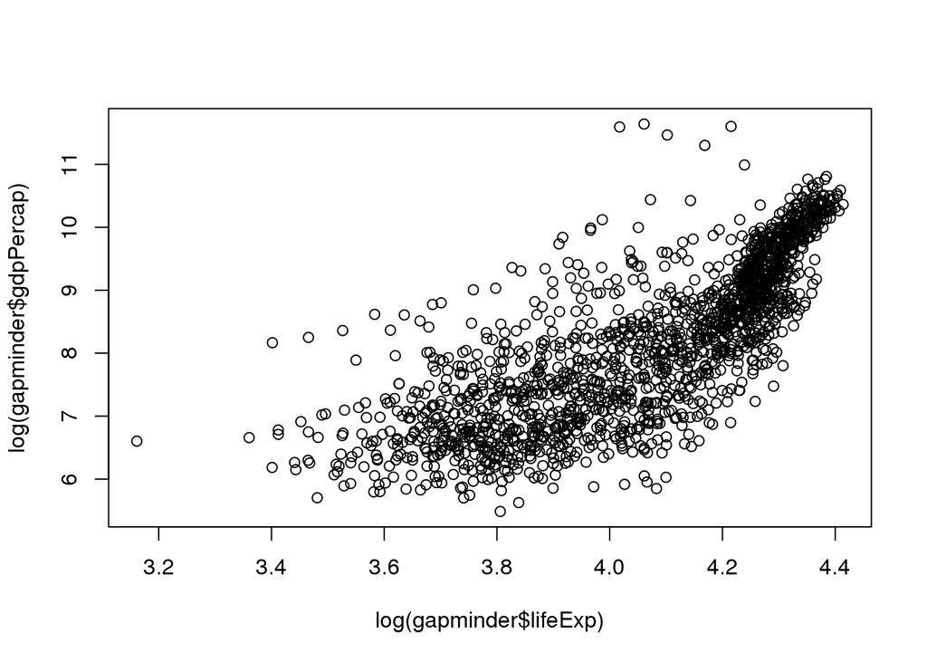

```r
plot(log(gapminder$gdpPercap) ~ log(gapminder$lifeExp))
```

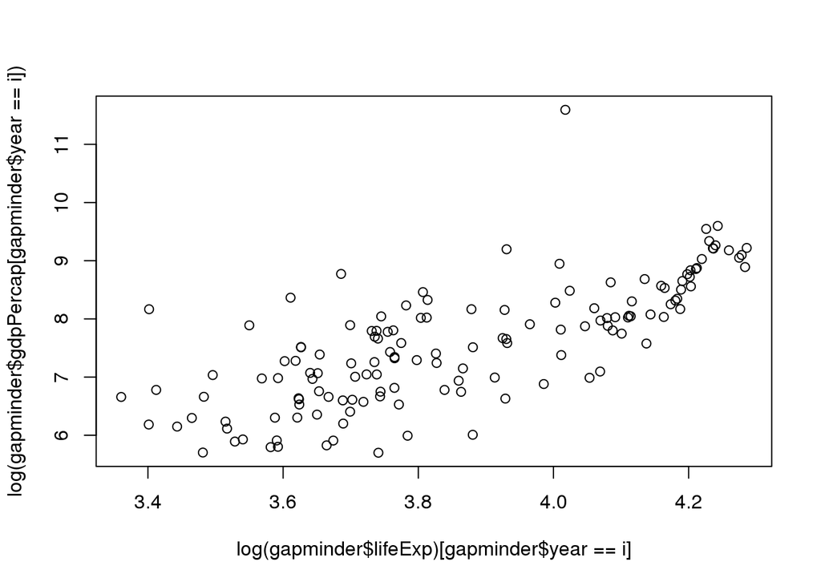

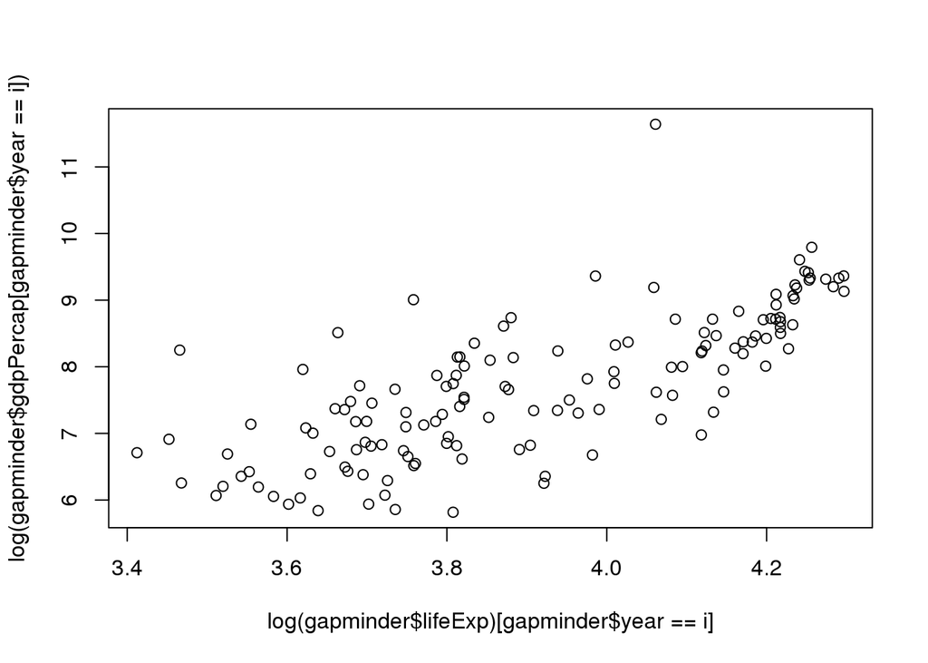

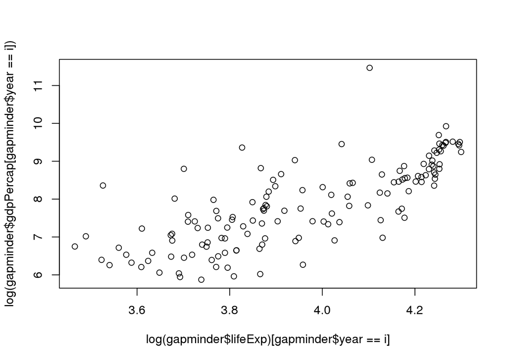

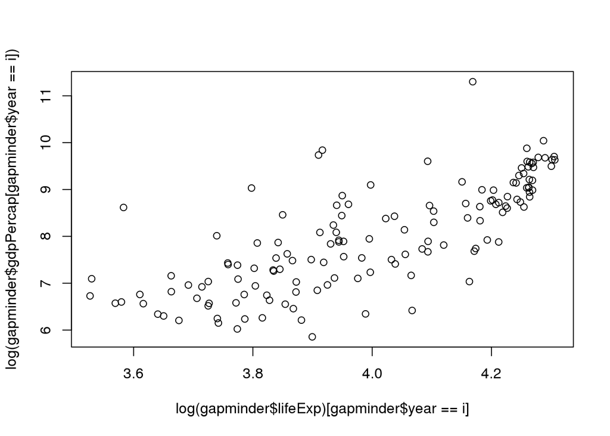

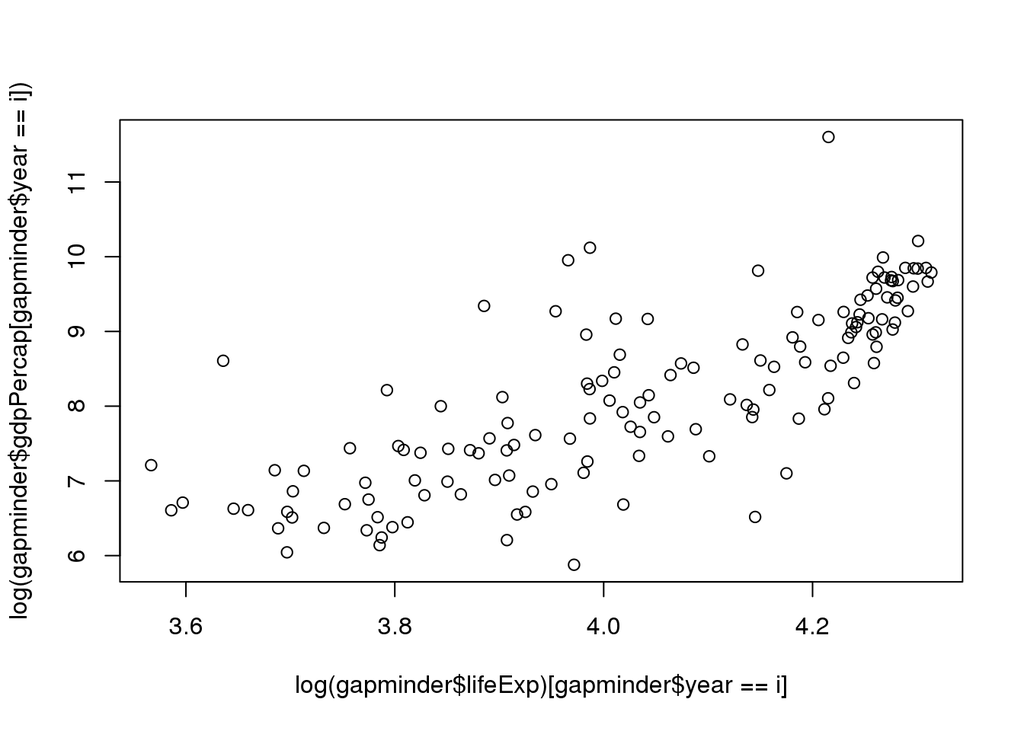

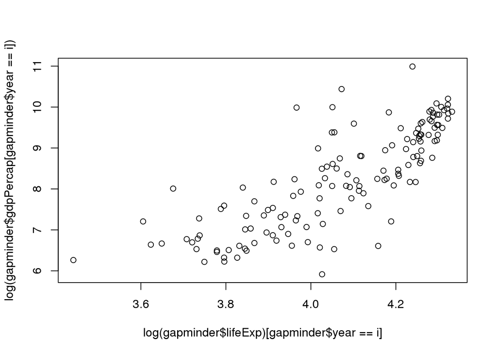

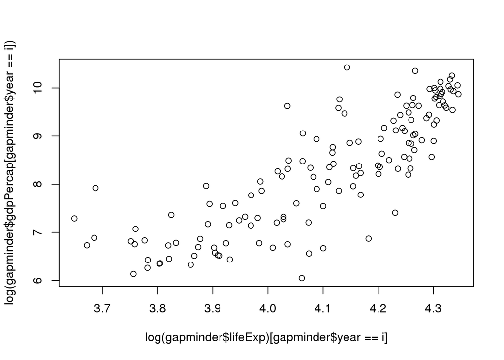

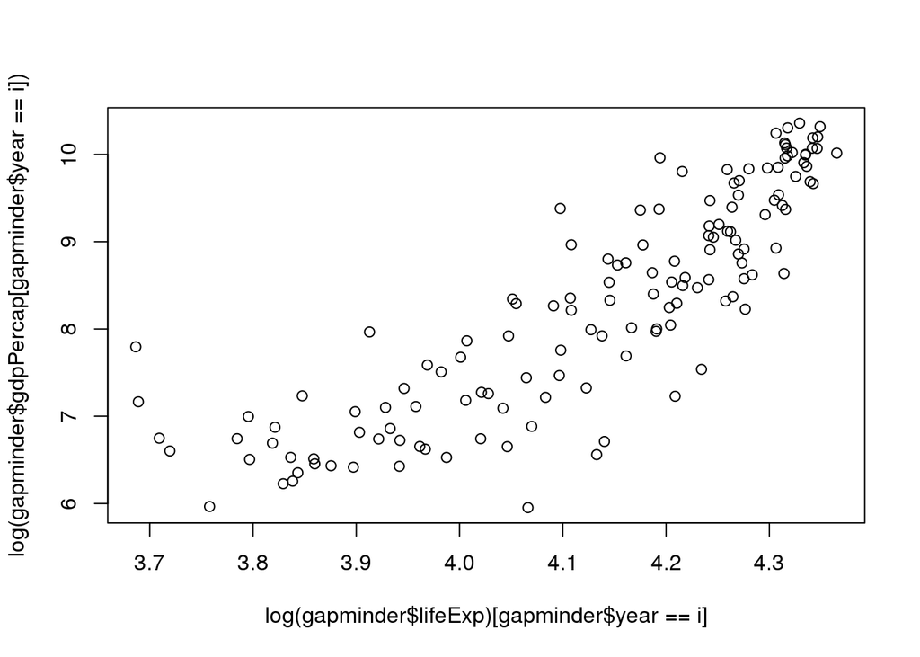

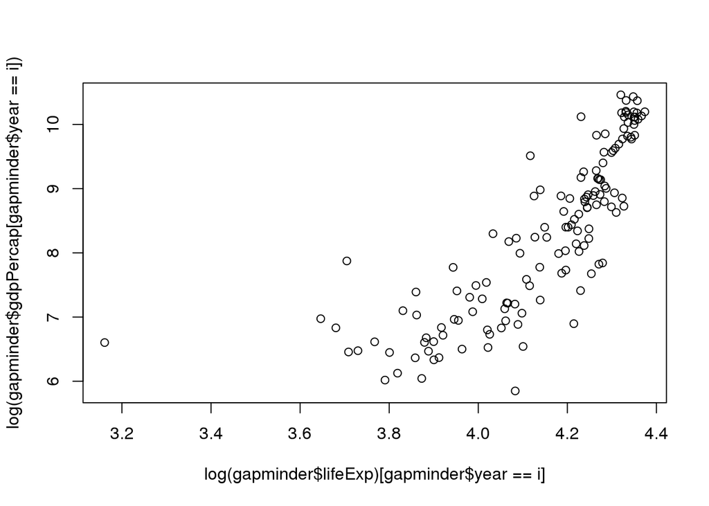

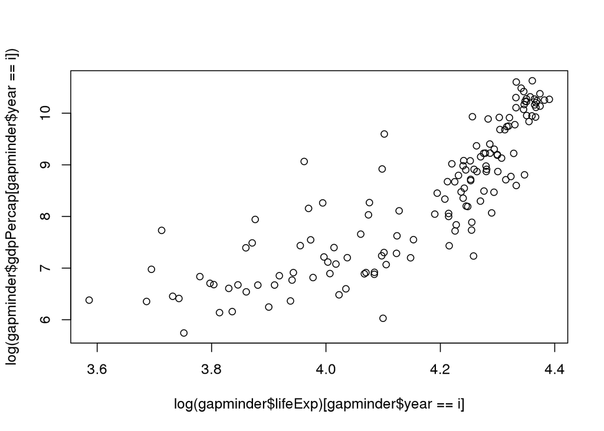

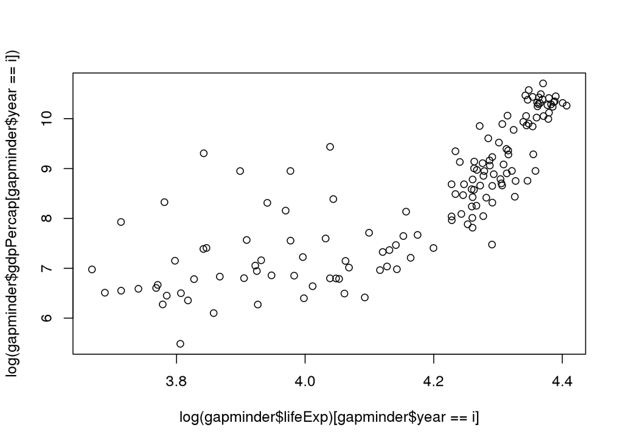

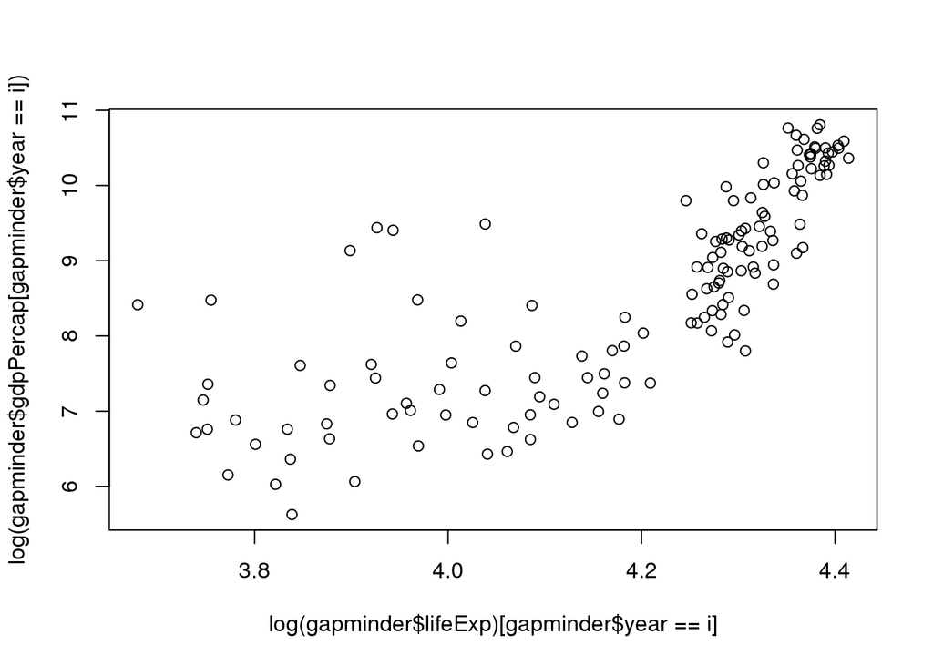

```r
for (i in unique(gapminder$year)){
  plot(log(gapminder$gdpPercap[gapminder$year == i]) ~ log(gapminder$lifeExp)[gapminder$year == i])
}
```

2. Does the relationship between GDP per capita and life expectacy vary by continent? Make sure you divide the Americas into North and South America.